# Chi Squared Test

```r
library(haven)
library(tidyverse)
library(mosaic)
library(pander)

gss2021 <- read_sas("../../Data/gss2021.sas7bdat",NULL)
```

## Background

In a world were people want to believe in something, there are groups of people that actually believe in Zodiac Signs. I respect their beliefs but i want to see if a zodiac sign has impact on a persons marital status. Could Libras really br crazy and Capricorns sneaky? Lets find out!

## Question And Hypothesis

For the Null Hypothesis its Marital status and star sign have no relation, but for the Alternative hypothesis i say that Star sign and Marital Status are related. So peoples star signs have a factor on their marital status.

Filtering data

```r
gss <- gss2021 |> select(c("ZODIAC","MARITAL"))|> filter(!is.na("ZODIAC" )& !is.na("MARITAl"))


gss <- gss |>
  mutate(
    Sign = case_when(
      ZODIAC == 1 ~ "Aries",
      ZODIAC == 2 ~ "Taurus",
      ZODIAC == 3 ~ "Gemini",
      ZODIAC == 4 ~ "Cancer",
      ZODIAC == 5 ~ "Leo",
      ZODIAC == 6 ~ "Virgo",
      ZODIAC == 7 ~ "Libra",
      ZODIAC == 8 ~ "Scorpio",
      ZODIAC == 9 ~ "Sagittarius",
      ZODIAC == 10 ~ "Capricorn",
      ZODIAC == 11 ~ "Aquarius",
      ZODIAC == 12 ~ "Pisces"))



gss <- gss |>
  mutate(
    Marital_stat = case_when(
      MARITAL == 1 ~ "Married",
       MARITAL == 2 ~ "Widowed",
       MARITAL == 3 ~ "Divorced",
       MARITAL == 4 ~ "Separated",
       MARITAL == 5 ~ "Never married"))
```

## Data Table

```r
my_zodiac <- table(gss$Sign,gss$Marital_stat)
my_zodiac |> pander()
```

|  | Divorced | Married | Never married | Separated | Widowed |
| --- | --- | --- | --- | --- | --- |
| **Aquarius** | 50 | 171 | 76 | 10 | 23 |
| **Aries** | 42 | 116 | 52 | 8 | 19 |
| **Cancer** | 41 | 123 | 78 | 11 | 15 |
| **Capricorn** | 48 | 213 | 88 | 11 | 30 |
| **Gemini** | 43 | 120 | 69 | 4 | 17 |
| **Leo** | 61 | 130 | 73 | 10 | 31 |
| **Libra** | 51 | 166 | 71 | 6 | 24 |
| **Pisces** | 47 | 129 | 77 | 5 | 20 |
| **Sagittarius** | 51 | 180 | 87 | 3 | 18 |
| **Scorpio** | 58 | 177 | 79 | 6 | 24 |
| **Taurus** | 49 | 132 | 74 | 6 | 20 |
| **Virgo** | 62 | 153 | 75 | 9 | 28 |

## Plot

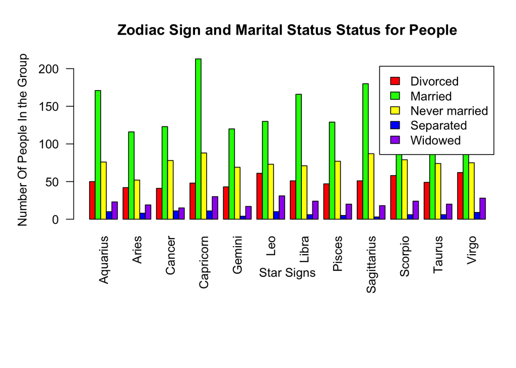

```r
par(mar=c(10,5,4,1))

barplot(t(my_zodiac),beside = TRUE, legend.text = TRUE, main = "Zodiac Sign and Marital Status Status for People",las=2, col = c ("red","green","yellow","blue","purple"), xlab = "Star Signs", ylab = "Number Of People In the Group")
```

## Zodiac Sign Chi squared Test

```r
chi_zodiac <- chisq.test(my_zodiac)
chi_zodiac |> pander()
```

Pearson’s Chi-squared test: `my_zodiac`

| Test statistic | df | P value |
| --- | --- | --- |
| 45.12 | 44 | 0.425 |

## Explanation

The P-value is higher than 0.05 so this means that there is no link between a persons Zodiac Sign and their marital Status.

## Fit test

```r
chi_zodiac$expected |> pander()
```

|  | Divorced | Married | Never married | Separated | Widowed |
| --- | --- | --- | --- | --- | --- |
| **Aquarius** | 54.22 | 162.8 | 80.84 | 8.003 | 24.19 |
| **Aries** | 38.94 | 116.9 | 58.06 | 5.747 | 17.37 |
| **Cancer** | 44.03 | 132.2 | 65.65 | 6.499 | 19.64 |
| **Capricorn** | 64.08 | 192.3 | 95.53 | 9.458 | 28.59 |
| **Gemini** | 41.57 | 124.8 | 61.97 | 6.135 | 18.54 |
| **Leo** | 50.11 | 150.4 | 74.71 | 7.396 | 22.36 |
| **Libra** | 52.25 | 156.8 | 77.9 | 7.712 | 23.31 |
| **Pisces** | 45.68 | 137.1 | 68.1 | 6.742 | 20.38 |
| **Sagittarius** | 55.7 | 167.2 | 83.04 | 8.221 | 24.85 |
| **Scorpio** | 56.52 | 169.7 | 84.27 | 8.342 | 25.21 |
| **Taurus** | 46.17 | 138.6 | 68.83 | 6.814 | 20.6 |
| **Virgo** | 53.73 | 161.3 | 80.1 | 7.93 | 23.97 |

## Explanation

The test for fit shows that non of the expected are less than 5 so that shows that the dataset fits properly. on average the expected are bigger than 5.

## Coclusion

Conclusively we can say that a persons relationship status has no link or corelation with their Zodiac sign. So contrary to what most people want to believe in the modern day world, their relationship status is impacted by some good and bad behaviors or rather some unforseen events that they have no control over.